# Ноутбук для семинара `Трекинг экспериментов`

Сегодня мы:

- рассмотрим пайплайн подготовки данных и обучения модели классификации доходов
- создадим эксперимент в MLflow и настроим логирование:
  - параметров
  - метрик
  - моделей
  - артефактов
- проведём серию запусков с изменением параметров и сравним результаты в UI MLflow

```python
# !pip install numpy datasets scikit-learn mlflow==2.22.1
```

## Импорты

```python
# импорты для пайплайна

import numpy as np
from datasets import load_dataset
from sklearn.compose import ColumnTransformer
from sklearn.linear_model import LogisticRegression
from sklearn.metrics import accuracy_score, f1_score, roc_auc_score, recall_score, precision_score, precision_recall_curve, auc
from sklearn.model_selection import train_test_split
from sklearn.pipeline import Pipeline
from sklearn.preprocessing import OrdinalEncoder, StandardScaler
from sklearn.ensemble import RandomForestClassifier
from catboost import CatBoostClassifier, Pool
import matplotlib.pyplot as plt
```

```python
import sklearn
import numpy
import datasets
import catboost
import matplotlib
import mlflow

numpy.__version__, sklearn.__version__, catboost.__version__, datasets.__version__, matplotlib.__version__, mlflow.__version__
```

```
('2.3.0', '1.8.0', '1.2.8', '4.0.0', '3.10.8', '2.22.1')
```

```python
mlflow.set_tracking_uri("http://158.160.242.172:5000/")
```

```python
mlflow.set_experiment(experiment_name="homework-mnkochnov.ext")
```

```
<Experiment: artifact_location='mlflow-artifacts:/6', creation_time=1776271096006, experiment_id='6', last_update_time=1776271096006, lifecycle_stage='active', name='homework-mnkochnov.ext', tags={}>
```

### Константы

```python
DATASET_NAME = "scikit-learn/adult-census-income"
TEST_SIZE = 0.3
RANDOM_STATE = 42
```

## Скачивание и подготовка данных

Скачаем данные

```python
dataset = load_dataset(DATASET_NAME)
```

Посмотрим на них и изучим

```python
dataset
```

```
DatasetDict({
    train: Dataset({
        features: ['age', 'workclass', 'fnlwgt', 'education', 'education.num', 'marital.status', 'occupation', 'relationship', 'race', 'sex', 'capital.gain', 'capital.loss', 'hours.per.week', 'native.country', 'income'],
        num_rows: 32561
    })
})
```

```python
dataset["train"].features
```

```
{'age': Value('int64'),
 'workclass': Value('string'),
 'fnlwgt': Value('int64'),
 'education': Value('string'),
 'education.num': Value('int64'),
 'marital.status': Value('string'),
 'occupation': Value('string'),
 'relationship': Value('string'),
 'race': Value('string'),
 'sex': Value('string'),
 'capital.gain': Value('int64'),
 'capital.loss': Value('int64'),
 'hours.per.week': Value('int64'),
 'native.country': Value('string'),
 'income': Value('string')}
```

```python
df = dataset["train"].to_pandas()
df
```

|  | age | workclass | fnlwgt | education | education.num | marital.status | occupation | relationship | race | sex | capital.gain | capital.loss | hours.per.week | native.country | income |
| --- | --- | --- | --- | --- | --- | --- | --- | --- | --- | --- | --- | --- | --- | --- | --- |
| 0 | 90 | ? | 77053 | HS-grad | 9 | Widowed | ? | Not-in-family | White | Female | 0 | 4356 | 40 | United-States | <=50K |
| 1 | 82 | Private | 132870 | HS-grad | 9 | Widowed | Exec-managerial | Not-in-family | White | Female | 0 | 4356 | 18 | United-States | <=50K |
| 2 | 66 | ? | 186061 | Some-college | 10 | Widowed | ? | Unmarried | Black | Female | 0 | 4356 | 40 | United-States | <=50K |
| 3 | 54 | Private | 140359 | 7th-8th | 4 | Divorced | Machine-op-inspct | Unmarried | White | Female | 0 | 3900 | 40 | United-States | <=50K |
| 4 | 41 | Private | 264663 | Some-college | 10 | Separated | Prof-specialty | Own-child | White | Female | 0 | 3900 | 40 | United-States | <=50K |
| ... | ... | ... | ... | ... | ... | ... | ... | ... | ... | ... | ... | ... | ... | ... | ... |
| 32556 | 22 | Private | 310152 | Some-college | 10 | Never-married | Protective-serv | Not-in-family | White | Male | 0 | 0 | 40 | United-States | <=50K |
| 32557 | 27 | Private | 257302 | Assoc-acdm | 12 | Married-civ-spouse | Tech-support | Wife | White | Female | 0 | 0 | 38 | United-States | <=50K |
| 32558 | 40 | Private | 154374 | HS-grad | 9 | Married-civ-spouse | Machine-op-inspct | Husband | White | Male | 0 | 0 | 40 | United-States | >50K |
| 32559 | 58 | Private | 151910 | HS-grad | 9 | Widowed | Adm-clerical | Unmarried | White | Female | 0 | 0 | 40 | United-States | <=50K |
| 32560 | 22 | Private | 201490 | HS-grad | 9 | Never-married | Adm-clerical | Own-child | White | Male | 0 | 0 | 20 | United-States | <=50K |

32561 rows × 15 columns

Описание признаков:

- `age` — возраст человека
- `workclass` — тип занятости
- `fnlwgt` — вес наблюдения в данных переписи населения США (сколько реальных людей в популяции «представляет» эта строка)
- `education` — образование
- `education.num` — уровень образования в виде числа
- `marital.status` — семейное положение
- `occupation` — профессия / род деятельности
- `relationship` — роль человека в семье
- `race` — расовая группа
- `sex` — пол человека (`Male` / `Female`)
- `capital.gain` — доход от капитала (прибыль от продажи активов)
- `capital.loss` — убытки от капитала
- `hours.per.week` — количество рабочих часов в неделю
- `native.country` — страна происхождения

Описание таргета:

- `income` — бинарно, получает человек больше 50k $ в год или нет

Оставим только часть признаков

```python
columns = ["age", "workclass", "education.num", "occupation", "marital.status", "sex", "capital.gain", "capital.loss", "hours.per.week"]

target_column = "income"
```

И разделим датафрейм на признаки и таргет

```python
X, y = df[columns], df[target_column]
```

```python
X
```

|  | age | workclass | education.num | occupation | marital.status | sex | capital.gain | capital.loss | hours.per.week |
| --- | --- | --- | --- | --- | --- | --- | --- | --- | --- |
| 0 | 90 | ? | 9 | ? | Widowed | Female | 0 | 4356 | 40 |
| 1 | 82 | Private | 9 | Exec-managerial | Widowed | Female | 0 | 4356 | 18 |
| 2 | 66 | ? | 10 | ? | Widowed | Female | 0 | 4356 | 40 |
| 3 | 54 | Private | 4 | Machine-op-inspct | Divorced | Female | 0 | 3900 | 40 |
| 4 | 41 | Private | 10 | Prof-specialty | Separated | Female | 0 | 3900 | 40 |
| ... | ... | ... | ... | ... | ... | ... | ... | ... | ... |
| 32556 | 22 | Private | 10 | Protective-serv | Never-married | Male | 0 | 0 | 40 |
| 32557 | 27 | Private | 12 | Tech-support | Married-civ-spouse | Female | 0 | 0 | 38 |
| 32558 | 40 | Private | 9 | Machine-op-inspct | Married-civ-spouse | Male | 0 | 0 | 40 |
| 32559 | 58 | Private | 9 | Adm-clerical | Widowed | Female | 0 | 0 | 40 |
| 32560 | 22 | Private | 9 | Adm-clerical | Never-married | Male | 0 | 0 | 20 |

32561 rows × 9 columns

```python
y
```

```
0        <=50K
1        <=50K
2        <=50K
3        <=50K
4        <=50K
         ...
32556    <=50K
32557    <=50K
32558     >50K
32559    <=50K
32560    <=50K
Name: income, Length: 32561, dtype: object
```

Используем Label Encoding для кодирования категориальных признаков

```python
cat_features = ["workclass", "occupation", "marital.status", "sex"]
num_features = list(set(columns) - set(cat_features))
```

```python
preprocessor = ColumnTransformer(
    transformers=[
        ("cat", OrdinalEncoder(), cat_features),
        ("num", StandardScaler(), num_features),
    ]
)
```

И закодируем целевую переменную

```python
y_transformed = (y == ">50K").astype(int)
```

```python
y_transformed
```

```
0        0
1        0
2        0
3        0
4        0
        ..
32556    0
32557    0
32558    1
32559    0
32560    0
Name: income, Length: 32561, dtype: int64
```

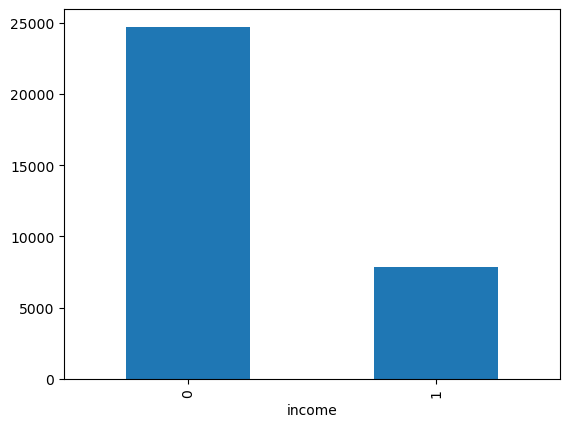

```python
y_transformed.value_counts().plot.bar();
```

Разделим на train и test

```python
X_train, X_test, y_train, y_test = train_test_split(X, y_transformed, test_size=TEST_SIZE, random_state=RANDOM_STATE)
```

```python
X_train.shape, X_test.shape, y_train.shape, y_test.shape
```

```
((22792, 9), (9769, 9), (22792,), (9769,))
```

## Обучение модели

```python
exp_name = "best_catboost"
```

```python
# lr_params = {"penalty": "l2", "C": 1, "solver": "lbfgs", "max_iter": 1000}
```

```python
# logreg = LogisticRegression(**lr_params, random_state=RANDOM_STATE)
# logreg
```

```python
# rf_params = {"n_estimators": 100, "criterion": "log_loss", "max_depth": 15, "min_samples_split": 10}
```

```python
# rf = RandomForestClassifier(**rf_params, random_state=RANDOM_STATE)
```

```python
cb_params = {'learning_rate': 0.1, 'depth': 5, 'early_stopping_rounds': 20}
```

```python
cb = CatBoostClassifier(**cb_params, eval_metric="AUC", use_best_model=True, random_state=RANDOM_STATE)
```

```python
train_pool = Pool(data=X_train, label=y_train, cat_features=cat_features, feature_names=list(X_train.columns))
test_pool = Pool(data=X_test, label=y_test, cat_features=cat_features, feature_names=list(X_test.columns))
```

```python
cb.fit(
    train_pool,
    eval_set=test_pool,
)
```

[output not shown]

[output not shown]

[output cut: 244 more lines]

```
329:	test: 0.9307166	best: 0.9307780 (317)	total: 8.39s	remaining: 17s
330:	test: 0.9307131	best: 0.9307780 (317)	total: 8.41s	remaining: 17s
331:	test: 0.9307283	best: 0.9307780 (317)	total: 8.43s	remaining: 17s
332:	test: 0.9307275	best: 0.9307780 (317)	total: 8.45s	remaining: 16.9s
333:	test: 0.9307365	best: 0.9307780 (317)	total: 8.47s	remaining: 16.9s
334:	test: 0.9307500	best: 0.9307780 (317)	total: 8.51s	remaining: 16.9s
335:	test: 0.9307699	best: 0.9307780 (317)	total: 8.54s	remaining: 16.9s
336:	test: 0.9307739	best: 0.9307780 (317)	total: 8.56s	remaining: 16.9s
337:	test: 0.9307418	best: 0.9307780 (317)	total: 8.6s	remaining: 16.8s
Stopped by overfitting detector  (20 iterations wait)

bestTest = 0.930778032
bestIteration = 317

Shrink model to first 318 iterations.
```

```
<catboost.core.CatBoostClassifier at 0x7f7d45807610>
```

Соберем пайплайн целиком

```python
# pipeline = Pipeline([("preprocess", preprocessor), ("model", rf)])
# pipeline
```

И запустим обучение

```python
# pipeline.fit(X_train, y_train)
# pipeline
```

## Оценка качества модели

Получим предсказания на тесте обученной модели

```python
# y_proba = pipeline.predict_proba(X_test)[:, 1]
y_proba = cb.predict_proba(X_test)[:, 1]
```

```python
y_proba.shape
```

```
(9769,)
```

```python
y_pred = np.where(y_proba >= 0.5, 1, 0)
```

Считаем метрики

```python
accuracy = accuracy_score(y_test, y_pred)
f1 = f1_score(y_test, y_pred)
roc_auc = roc_auc_score(y_test, y_proba)
precision = precision_score(y_test, y_pred)
recall = recall_score(y_test, y_pred)

prec, rec, thresholds = precision_recall_curve(y_test, y_proba)
pr_auc = auc(rec, prec)
```

```python
print(f"Accuracy: {accuracy:.4f}")
print(f"F1-score: {f1:.4f}")
print(f"ROC-AUC: {roc_auc:.4f}")
print(f"Precision: {precision:.4f}")
print(f"Recall: {recall:.4f}")
print(f"PR-AUC: {pr_auc:.4f}")
```

```
Accuracy: 0.8762
F1-score: 0.7149
ROC-AUC: 0.9308
Precision: 0.7975
Recall: 0.6479
PR-AUC: 0.8323
```

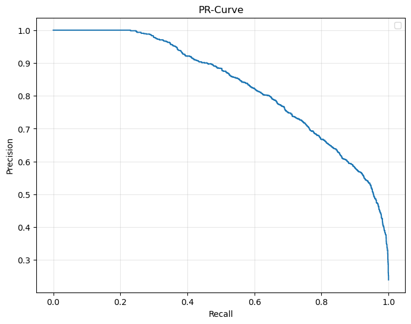

```python
fig = plt.figure(figsize=(8, 6))

plt.plot(rec, prec)

plt.xlabel("Recall")
plt.ylabel("Precision")
plt.title("PR-Curve")
plt.legend()
plt.grid(True, alpha=0.3)
```

```python
data_params = {
    "test_size": TEST_SIZE,
    "cat_encoder": pipeline.get_params()["steps"][0][1].get_params()["transformers"][0][1].__class__.__name__,
    "num_encoder": pipeline.get_params()["steps"][0][1].get_params()["transformers"][1][1].__class__.__name__,
}

input_example = X_train.iloc[[0]]
```

```python
with mlflow.start_run(run_name=exp_name):
    mlflow.log_metrics({"accuracy": accuracy, "f1_score": f1, "roc_auc": roc_auc, "precision": precision, "recall": recall, "pr_auc": pr_auc})
    # mlflow.log_params(dict(lr_params, **{'model_type': 'LogisticRegression'}, **data_params))
    # mlflow.log_params(dict(rf_params, **{'model_type': 'RandomForest'}, **data_params))
    mlflow.log_params(dict(cb_params, **{"model_type": "CatBoost", "test_size": TEST_SIZE}))

    mlflow.log_figure(fig, "plots/pr_curve.png")
    # mlflow.sklearn.log_model(pipeline, artifact_path="model", input_example=input_example)
    mlflow.catboost.log_model(cb, artifact_path="model", input_example=input_example)

plt.close(fig)
```